# Basics of Data Analysis using R (Part 2)

## Load packages

```r
ipak <- function(pkg){
        new.pkg <- pkg[!(pkg %in% installed.packages()[, "Package"])]
        if (length(new.pkg))
                install.packages(new.pkg, dependencies = TRUE)
        sapply(pkg, require, character.only = TRUE)
}

# usage
packages <- c("ggplot2", "Rmisc", "tidyr", "RColorBrewer", "plotly", "ggplot2", "nlme", "dplyr", "cowplot", "grid", "gridExtra", "reshape", "plyr", "psych") # add or remove packages as needed
ipak(packages)
```

```
##      ggplot2        Rmisc        tidyr RColorBrewer       plotly
##         TRUE         TRUE         TRUE         TRUE         TRUE
##      ggplot2         nlme        dplyr      cowplot         grid
##         TRUE         TRUE         TRUE         TRUE         TRUE
##    gridExtra      reshape         plyr        psych
##         TRUE         TRUE         TRUE         TRUE
```

# Importing and cleaning data

## Import data

```r
#Load dataset
mydataset <- read.csv("data/Sample-Dose-Effect-Curve.csv")

#Explore dataset
summary(mydataset)
```

```
##     Subject          StartDate   Drug     IV.Sex    DV.Activity
##  Min.   :8640   1/24/2012 :24   Bup:144   Fem:72   Min.   :  0.0
##  1st Qu.:8646   1/29/2012 :24             M  :72   1st Qu.: 82.0
##  Median :8652   1/4/2012  :24                      Median :112.5
##  Mean   :8652   1/9/2012  :24                      Mean   :118.7
##  3rd Qu.:8657   12/20/2011:24                      3rd Qu.:152.2
##  Max.   :8663   12/30/2011:24                      Max.   :324.0
##     IV.DOSE       DV.Response
##  Min.   : 0.00   Min.   :0.00000
##  1st Qu.: 5.00   1st Qu.:0.04167
##  Median :15.00   Median :0.08333
##  Mean   :20.83   Mean   :0.12674
##  3rd Qu.:30.00   3rd Qu.:0.18021
##  Max.   :60.00   Max.   :1.00417
```

```r
str(mydataset)
```

```
## 'data.frame':    144 obs. of  7 variables:
##  $ Subject    : int  8652 8653 8654 8655 8656 8657 8658 8659 8660 8661 ...
##  $ StartDate  : Factor w/ 6 levels "1/24/2012","1/29/2012",..: 5 6 6 3 3 3 6 5 6 6 ...
##  $ Drug       : Factor w/ 1 level "Bup": 1 1 1 1 1 1 1 1 1 1 ...
##  $ IV.Sex     : Factor w/ 2 levels "Fem","M": 1 1 1 1 1 1 1 1 1 1 ...
##  $ DV.Activity: int  69 48 78 126 108 126 211 60 95 120 ...
##  $ IV.DOSE    : int  0 0 0 0 0 0 0 0 0 0 ...
##  $ DV.Response: num  0.0208 0.1333 0.0583 0.1208 0.0958 ...
```

## Rename columns

```r
mydataset<-rename(mydataset, c("IV.Sex"="Sex", "DV.Activity"="Activity", "IV.DOSE"="DOSE", "DV.Response"="Response"))
str(mydataset)
```

```
## 'data.frame':    144 obs. of  7 variables:
##  $ Subject  : int  8652 8653 8654 8655 8656 8657 8658 8659 8660 8661 ...
##  $ StartDate: Factor w/ 6 levels "1/24/2012","1/29/2012",..: 5 6 6 3 3 3 6 5 6 6 ...
##  $ Drug     : Factor w/ 1 level "Bup": 1 1 1 1 1 1 1 1 1 1 ...
##  $ Sex      : Factor w/ 2 levels "Fem","M": 1 1 1 1 1 1 1 1 1 1 ...
##  $ Activity : int  69 48 78 126 108 126 211 60 95 120 ...
##  $ DOSE     : int  0 0 0 0 0 0 0 0 0 0 ...
##  $ Response : num  0.0208 0.1333 0.0583 0.1208 0.0958 ...
```

## Convert variables to factors

```r
mydataset$Subject<-as.factor(mydataset$Subject)
mydataset$DOSE<-as.factor(mydataset$DOSE)

#Explore dataset
summary(mydataset)
```

```
##     Subject         StartDate   Drug      Sex        Activity     DOSE
##  8640   :  6   1/24/2012 :24   Bup:144   Fem:72   Min.   :  0.0   0 :24
##  8641   :  6   1/29/2012 :24             M  :72   1st Qu.: 82.0   5 :24
##  8642   :  6   1/4/2012  :24                      Median :112.5   10:24
##  8643   :  6   1/9/2012  :24                      Mean   :118.7   20:24
##  8644   :  6   12/20/2011:24                      3rd Qu.:152.2   30:24
##  8645   :  6   12/30/2011:24                      Max.   :324.0   60:24
##  (Other):108
##     Response
##  Min.   :0.00000
##  1st Qu.:0.04167
##  Median :0.08333
##  Mean   :0.12674
##  3rd Qu.:0.18021
##  Max.   :1.00417
##
```

```r
str(mydataset)
```

```
## 'data.frame':    144 obs. of  7 variables:
##  $ Subject  : Factor w/ 24 levels "8640","8641",..: 13 14 15 16 17 18 19 20 21 22 ...
##  $ StartDate: Factor w/ 6 levels "1/24/2012","1/29/2012",..: 5 6 6 3 3 3 6 5 6 6 ...
##  $ Drug     : Factor w/ 1 level "Bup": 1 1 1 1 1 1 1 1 1 1 ...
##  $ Sex      : Factor w/ 2 levels "Fem","M": 1 1 1 1 1 1 1 1 1 1 ...
##  $ Activity : int  69 48 78 126 108 126 211 60 95 120 ...
##  $ DOSE     : Factor w/ 6 levels "0","5","10","20",..: 1 1 1 1 1 1 1 1 1 1 ...
##  $ Response : num  0.0208 0.1333 0.0583 0.1208 0.0958 ...
```

## Rename level of a factor

```r
with(mydataset, (levels(Sex)))
```

```
## [1] "Fem" "M"
```

```r
mydataset$Sex<-with(mydataset, revalue(Sex, c("Fem"="F")))
str(mydataset)
```

```
## 'data.frame':    144 obs. of  7 variables:
##  $ Subject  : Factor w/ 24 levels "8640","8641",..: 13 14 15 16 17 18 19 20 21 22 ...
##  $ StartDate: Factor w/ 6 levels "1/24/2012","1/29/2012",..: 5 6 6 3 3 3 6 5 6 6 ...
##  $ Drug     : Factor w/ 1 level "Bup": 1 1 1 1 1 1 1 1 1 1 ...
##  $ Sex      : Factor w/ 2 levels "F","M": 1 1 1 1 1 1 1 1 1 1 ...
##  $ Activity : int  69 48 78 126 108 126 211 60 95 120 ...
##  $ DOSE     : Factor w/ 6 levels "0","5","10","20",..: 1 1 1 1 1 1 1 1 1 1 ...
##  $ Response : num  0.0208 0.1333 0.0583 0.1208 0.0958 ...
```

## Subset

```r
### Subset dataset for separate analysis if needed
Female<-subset(mydataset, Sex=="F")
Male<-subset(mydataset, Sex=="M")

summary(Female)
```

```
##     Subject        StartDate   Drug    Sex       Activity      DOSE
##  8652   : 6   1/24/2012 :12   Bup:72   F:72   Min.   :  0.00   0 :12
##  8653   : 6   1/29/2012 :12            M: 0   1st Qu.: 82.75   5 :12
##  8654   : 6   1/4/2012  :12                   Median :119.00   10:12
##  8655   : 6   1/9/2012  :12                   Mean   :127.78   20:12
##  8656   : 6   12/20/2011:12                   3rd Qu.:173.00   30:12
##  8657   : 6   12/30/2011:12                   Max.   :324.00   60:12
##  (Other):36
##     Response
##  Min.   :0.00000
##  1st Qu.:0.04479
##  Median :0.08333
##  Mean   :0.12054
##  3rd Qu.:0.14583
##  Max.   :1.00417
##
```

```r
summary(Male)
```

```
##     Subject        StartDate   Drug    Sex       Activity      DOSE
##  8640   : 6   1/24/2012 :12   Bup:72   F: 0   Min.   :  0.00   0 :12
##  8641   : 6   1/29/2012 :12            M:72   1st Qu.: 81.25   5 :12
##  8642   : 6   1/4/2012  :12                   Median :105.50   10:12
##  8643   : 6   1/9/2012  :12                   Mean   :109.64   20:12
##  8644   : 6   12/20/2011:12                   3rd Qu.:134.25   30:12
##  8645   : 6   12/30/2011:12                   Max.   :265.00   60:12
##  (Other):36
##     Response
##  Min.   :0.00000
##  1st Qu.:0.04063
##  Median :0.08542
##  Mean   :0.13293
##  3rd Qu.:0.20208
##  Max.   :0.58750
##
```

## Basic summary statistics using Psych package

```r
#Basic summary statistics by group
with(mydataset, (describeBy(Response, list(DOSE, Sex), mat=TRUE)))
```

```
##      item group1 group2 vars  n       mean         sd     median
## X11     1      0      F    1 12 0.06423611 0.03914564 0.06250000
## X12     2      5      F    1 12 0.10486111 0.05080890 0.10833333
## X13     3     10      F    1 12 0.14479167 0.06965656 0.13333333
## X14     4     20      F    1 12 0.11006944 0.08037276 0.08333333
## X15     5     30      F    1 12 0.17361111 0.14021463 0.17916667
## X16     6     60      F    1 12 0.12569444 0.27952450 0.03333333
## X17     7      0      M    1 12 0.04131944 0.02285345 0.04375000
## X18     8      5      M    1 12 0.11319444 0.08496199 0.09375000
## X19     9     10      M    1 12 0.21631944 0.14343216 0.18125000
## X110   10     20      M    1 12 0.16979167 0.11551276 0.18750000
## X111   11     30      M    1 12 0.12673611 0.16737028 0.06250000
## X112   12     60      M    1 12 0.13020833 0.09705455 0.09583333
##         trimmed        mad         min       max     range        skew
## X11  0.06250000 0.04324250 0.012500000 0.1333333 0.1208333  0.32705234
## X12  0.10250000 0.04324250 0.037500000 0.1958333 0.1583333  0.29367973
## X13  0.13416667 0.03397625 0.070833333 0.3250000 0.2541667  1.34977754
## X14  0.10458333 0.09575125 0.012500000 0.2625000 0.2500000  0.39680714
## X15  0.16125000 0.18841375 0.029166667 0.4416667 0.4125000  0.63216106
## X16  0.05041667 0.02779875 0.000000000 1.0041667 1.0041667  2.55265082
## X17  0.04083333 0.03397625 0.012500000 0.0750000 0.0625000  0.06855280
## X18  0.10708333 0.07721875 0.012500000 0.2750000 0.2625000  0.55560713
## X19  0.20000000 0.14208250 0.062500000 0.5333333 0.4708333  0.78155271
## X110 0.16750000 0.11119500 0.000000000 0.3625000 0.3625000 -0.01501116
## X111 0.09291667 0.08030750 0.004166667 0.5875000 0.5833333  1.63369824
## X112 0.12250000 0.09266250 0.033333333 0.3041667 0.2708333  0.45859131
##        kurtosis          se
## X11  -1.2616843 0.011300373
## X12  -1.1717699 0.014667267
## X13   1.0907902 0.020108116
## X14  -1.2076387 0.023201617
## X15  -0.9620284 0.040476478
## X16   5.1421563 0.080691771
## X17  -1.6439831 0.006597222
## X18  -1.2120775 0.024526414
## X19  -0.5081075 0.041405299
## X110 -1.3447682 0.033345661
## X111  1.9027167 0.048315638
## X112 -1.4762354 0.028017237
```

```r
# How about a nicer view of this table
library(knitr) # use knitr package
# use kable function
kable(with(mydataset, (describeBy(Response, list(DOSE, Sex), mat=TRUE))))
```

|  | item | group1 | group2 | vars | n | mean | sd | median | trimmed | mad | min | max | range | skew | kurtosis | se |
| --- | --- | --- | --- | --- | --- | --- | --- | --- | --- | --- | --- | --- | --- | --- | --- | --- |
| X11 | 1 | 0 | F | 1 | 12 | 0.0642361 | 0.0391456 | 0.0625000 | 0.0625000 | 0.0432425 | 0.0125000 | 0.1333333 | 0.1208333 | 0.3270523 | -1.2616843 | 0.0113004 |
| X12 | 2 | 5 | F | 1 | 12 | 0.1048611 | 0.0508089 | 0.1083333 | 0.1025000 | 0.0432425 | 0.0375000 | 0.1958333 | 0.1583333 | 0.2936797 | -1.1717699 | 0.0146673 |
| X13 | 3 | 10 | F | 1 | 12 | 0.1447917 | 0.0696566 | 0.1333333 | 0.1341667 | 0.0339763 | 0.0708333 | 0.3250000 | 0.2541667 | 1.3497775 | 1.0907902 | 0.0201081 |
| X14 | 4 | 20 | F | 1 | 12 | 0.1100694 | 0.0803728 | 0.0833333 | 0.1045833 | 0.0957512 | 0.0125000 | 0.2625000 | 0.2500000 | 0.3968071 | -1.2076387 | 0.0232016 |
| X15 | 5 | 30 | F | 1 | 12 | 0.1736111 | 0.1402146 | 0.1791667 | 0.1612500 | 0.1884137 | 0.0291667 | 0.4416667 | 0.4125000 | 0.6321611 | -0.9620284 | 0.0404765 |
| X16 | 6 | 60 | F | 1 | 12 | 0.1256944 | 0.2795245 | 0.0333333 | 0.0504167 | 0.0277987 | 0.0000000 | 1.0041667 | 1.0041667 | 2.5526508 | 5.1421563 | 0.0806918 |
| X17 | 7 | 0 | M | 1 | 12 | 0.0413194 | 0.0228534 | 0.0437500 | 0.0408333 | 0.0339763 | 0.0125000 | 0.0750000 | 0.0625000 | 0.0685528 | -1.6439831 | 0.0065972 |
| X18 | 8 | 5 | M | 1 | 12 | 0.1131944 | 0.0849620 | 0.0937500 | 0.1070833 | 0.0772187 | 0.0125000 | 0.2750000 | 0.2625000 | 0.5556071 | -1.2120775 | 0.0245264 |
| X19 | 9 | 10 | M | 1 | 12 | 0.2163194 | 0.1434322 | 0.1812500 | 0.2000000 | 0.1420825 | 0.0625000 | 0.5333333 | 0.4708333 | 0.7815527 | -0.5081075 | 0.0414053 |
| X110 | 10 | 20 | M | 1 | 12 | 0.1697917 | 0.1155128 | 0.1875000 | 0.1675000 | 0.1111950 | 0.0000000 | 0.3625000 | 0.3625000 | -0.0150112 | -1.3447682 | 0.0333457 |
| X111 | 11 | 30 | M | 1 | 12 | 0.1267361 | 0.1673703 | 0.0625000 | 0.0929167 | 0.0803075 | 0.0041667 | 0.5875000 | 0.5833333 | 1.6336982 | 1.9027167 | 0.0483156 |
| X112 | 12 | 60 | M | 1 | 12 | 0.1302083 | 0.0970546 | 0.0958333 | 0.1225000 | 0.0926625 | 0.0333333 | 0.3041667 | 0.2708333 | 0.4585913 | -1.4762354 | 0.0280172 |

## Preliminary visualization

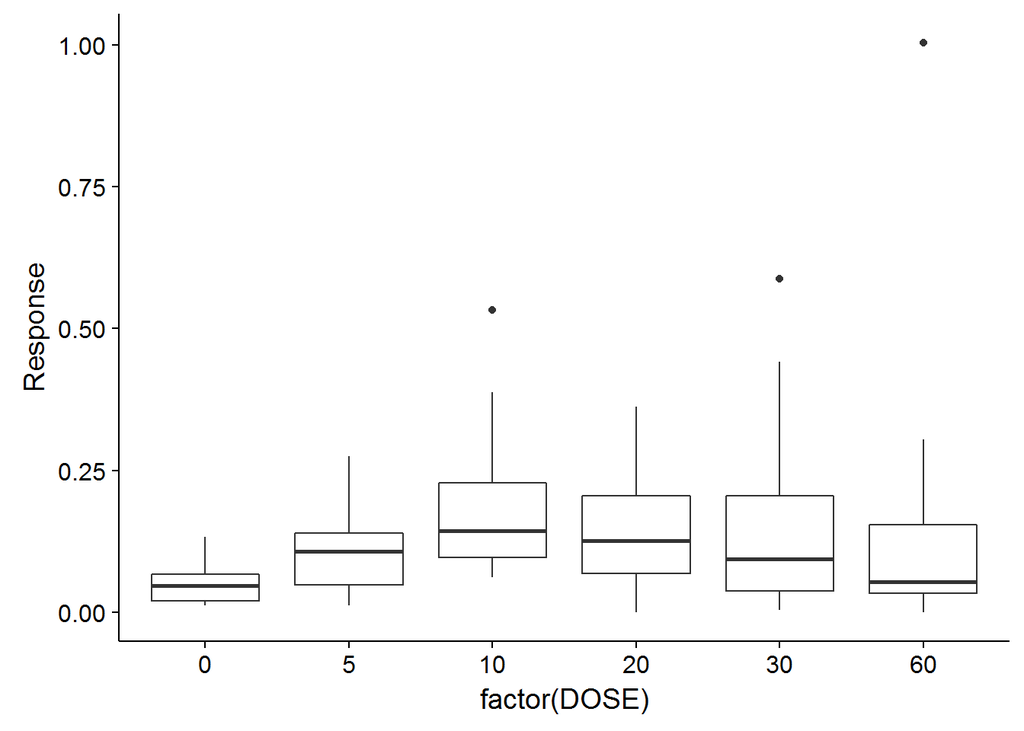

```r
#Boxplot
p<-ggplot(mydataset, aes(factor(DOSE), Response))
p+geom_boxplot()
```

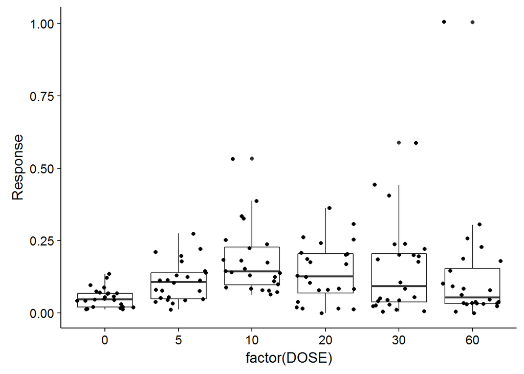

```r
# save boxplot as bp1
bp1<-ggplot(mydataset, aes(factor(DOSE), Response))+
  geom_boxplot()


#Boxplot with individual data
p<-ggplot(mydataset, aes(factor(DOSE), Response))
p+geom_boxplot() +
geom_jitter()
```

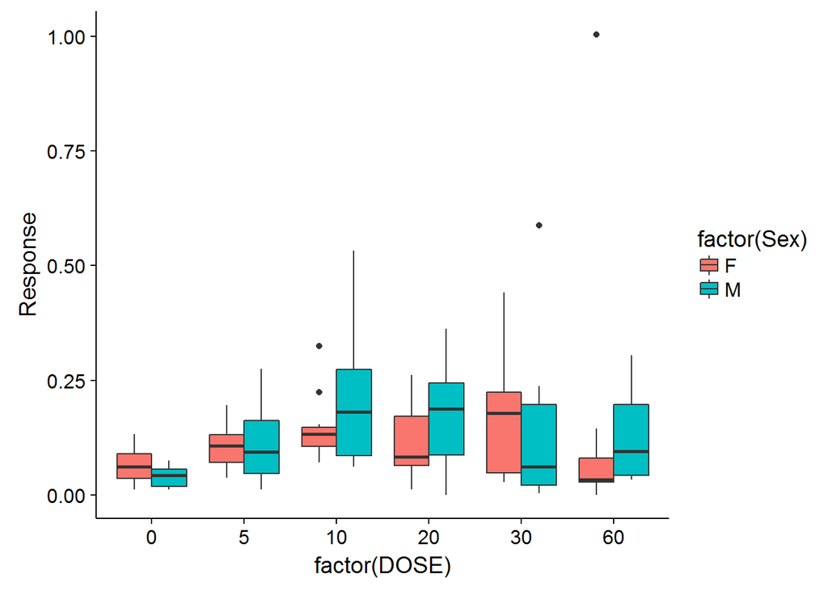

```r
# save as bp2
bp2<-ggplot(mydataset, aes(factor(DOSE), Response))+
  geom_boxplot() +
  geom_jitter()


#Boxplot: by Sex
p<-ggplot(mydataset, aes(factor(DOSE), Response))
p+geom_boxplot(aes(fill=factor(Sex)))
```

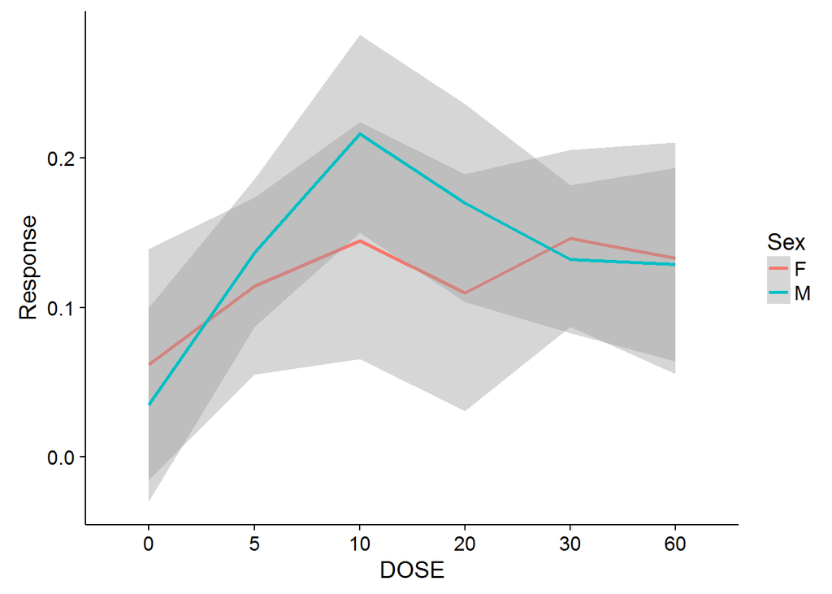

```r
# save as bp3

bp3<-ggplot(mydataset, aes(factor(DOSE), Response))+
  geom_boxplot(aes(fill=factor(Sex)))


#Line plot: DOSE by Sex

ggplot(mydataset, aes(x=DOSE, y=Response, colour=Sex, group=Sex)) +
  geom_smooth()
```

# Multiple (Linear) Regression

```r
# Comparing models
fit0<-lm(Response~1, data=mydataset)
fit1<-lm(Response~DOSE, data=mydataset)
fit2<-lm(Response~DOSE+Sex, data=mydataset)
anova(fit0,fit1,fit2)
```

```
## Analysis of Variance Table
##
## Model 1: Response ~ 1
## Model 2: Response ~ DOSE
## Model 3: Response ~ DOSE + Sex
##   Res.Df    RSS Df Sum of Sq      F  Pr(>F)
## 1    143 2.4101
## 2    138 2.1844  5  0.225716 2.8385 0.01799 *
## 3    137 2.1789  1  0.005521 0.3472 0.55669
## ---
## Signif. codes:  0 '***' 0.001 '**' 0.01 '*' 0.05 '.' 0.1 ' ' 1
```

```r
# Fitting model
fit <- lm(Response~DOSE+Sex, data=mydataset)
anova(fit) # anova table
```

```
## Analysis of Variance Table
##
## Response: Response
##            Df  Sum Sq  Mean Sq F value  Pr(>F)
## DOSE        5 0.22572 0.045143  2.8385 0.01799 *
## Sex         1 0.00552 0.005521  0.3472 0.55669
## Residuals 137 2.17885 0.015904
## ---
## Signif. codes:  0 '***' 0.001 '**' 0.01 '*' 0.05 '.' 0.1 ' ' 1
```

```r
summary(fit)
```

```
##
## Call:
## lm(formula = Response ~ DOSE + Sex, data = mydataset)
##
## Residuals:
##      Min       1Q   Median       3Q      Max
## -0.15220 -0.08248 -0.02367  0.04608  0.88241
##
## Coefficients:
##             Estimate Std. Error t value Pr(>|t|)
## (Intercept)  0.04659    0.02780   1.675 0.096127 .
## DOSE5        0.05625    0.03641   1.545 0.124626
## DOSE10       0.12778    0.03641   3.510 0.000607 ***
## DOSE20       0.08715    0.03641   2.394 0.018021 *
## DOSE30       0.09740    0.03641   2.675 0.008375 **
## DOSE60       0.07517    0.03641   2.065 0.040816 *
## SexM         0.01238    0.02102   0.589 0.556693
## ---
## Signif. codes:  0 '***' 0.001 '**' 0.01 '*' 0.05 '.' 0.1 ' ' 1
##
## Residual standard error: 0.1261 on 137 degrees of freedom
## Multiple R-squared:  0.09595,    Adjusted R-squared:  0.05635
## F-statistic: 2.423 on 6 and 137 DF,  p-value: 0.02944
```

```r
fit <- lm(Response~DOSE*Sex, data=mydataset)
anova(fit) # anova table
```

```
## Analysis of Variance Table
##
## Response: Response
##            Df  Sum Sq  Mean Sq F value  Pr(>F)
## DOSE        5 0.22572 0.045143  2.8169 0.01887 *
## Sex         1 0.00552 0.005521  0.3445 0.55823
## DOSE:Sex    5 0.06345 0.012690  0.7919 0.55735
## Residuals 132 2.11540 0.016026
## ---
## Signif. codes:  0 '***' 0.001 '**' 0.01 '*' 0.05 '.' 0.1 ' ' 1
```

```r
summary(fit)
```

```
##
## Call:
## lm(formula = Response ~ DOSE * Sex, data = mydataset)
##
## Residuals:
##      Min       1Q   Median       3Q      Max
## -0.16979 -0.07214 -0.02014  0.03472  0.87847
##
## Coefficients:
##             Estimate Std. Error t value Pr(>|t|)
## (Intercept)  0.06424    0.03654   1.758   0.0811 .
## DOSE5        0.04063    0.05168   0.786   0.4332
## DOSE10       0.08056    0.05168   1.559   0.1215
## DOSE20       0.04583    0.05168   0.887   0.3768
## DOSE30       0.10938    0.05168   2.116   0.0362 *
## DOSE60       0.06146    0.05168   1.189   0.2365
## SexM        -0.02292    0.05168  -0.443   0.6582
## DOSE5:SexM   0.03125    0.07309   0.428   0.6697
## DOSE10:SexM  0.09444    0.07309   1.292   0.1985
## DOSE20:SexM  0.08264    0.07309   1.131   0.2602
## DOSE30:SexM -0.02396    0.07309  -0.328   0.7436
## DOSE60:SexM  0.02743    0.07309   0.375   0.7080
## ---
## Signif. codes:  0 '***' 0.001 '**' 0.01 '*' 0.05 '.' 0.1 ' ' 1
##
## Residual standard error: 0.1266 on 132 degrees of freedom
## Multiple R-squared:  0.1223, Adjusted R-squared:  0.04913
## F-statistic: 1.672 on 11 and 132 DF,  p-value: 0.08655
```

```r
# Other useful functions
coefficients(fit) # model coefficients
```

```
## (Intercept)       DOSE5      DOSE10      DOSE20      DOSE30      DOSE60
##  0.06423611  0.04062500  0.08055556  0.04583333  0.10937500  0.06145833
##        SexM  DOSE5:SexM DOSE10:SexM DOSE20:SexM DOSE30:SexM DOSE60:SexM
## -0.02291667  0.03125000  0.09444444  0.08263889 -0.02395833  0.02743056
```

```r
confint(fit, level=0.95) # CIs for model parameters
```

```
##                    2.5 %     97.5 %
## (Intercept) -0.008051951 0.13652417
## DOSE5       -0.061605757 0.14285576
## DOSE10      -0.021675201 0.18278631
## DOSE20      -0.056397423 0.14806409
## DOSE30       0.007144243 0.21160576
## DOSE60      -0.040772424 0.16368909
## SexM        -0.125147423 0.07931409
## DOSE5:SexM  -0.113326123 0.17582612
## DOSE10:SexM -0.050131679 0.23902057
## DOSE20:SexM -0.061937234 0.22721501
## DOSE30:SexM -0.168534457 0.12061779
## DOSE60:SexM -0.117145568 0.17200668
```

```r
vcov(fit) # covariance matrix for model parameters
```

```
##              (Intercept)        DOSE5       DOSE10       DOSE20
## (Intercept)  0.001335479 -0.001335479 -0.001335479 -0.001335479
## DOSE5       -0.001335479  0.002670959  0.001335479  0.001335479
## DOSE10      -0.001335479  0.001335479  0.002670959  0.001335479
## DOSE20      -0.001335479  0.001335479  0.001335479  0.002670959
## DOSE30      -0.001335479  0.001335479  0.001335479  0.001335479
## DOSE60      -0.001335479  0.001335479  0.001335479  0.001335479
## SexM        -0.001335479  0.001335479  0.001335479  0.001335479
## DOSE5:SexM   0.001335479 -0.002670959 -0.001335479 -0.001335479
## DOSE10:SexM  0.001335479 -0.001335479 -0.002670959 -0.001335479
## DOSE20:SexM  0.001335479 -0.001335479 -0.001335479 -0.002670959
## DOSE30:SexM  0.001335479 -0.001335479 -0.001335479 -0.001335479
## DOSE60:SexM  0.001335479 -0.001335479 -0.001335479 -0.001335479
##                   DOSE30       DOSE60         SexM   DOSE5:SexM
## (Intercept) -0.001335479 -0.001335479 -0.001335479  0.001335479
## DOSE5        0.001335479  0.001335479  0.001335479 -0.002670959
## DOSE10       0.001335479  0.001335479  0.001335479 -0.001335479
## DOSE20       0.001335479  0.001335479  0.001335479 -0.001335479
## DOSE30       0.002670959  0.001335479  0.001335479 -0.001335479
## DOSE60       0.001335479  0.002670959  0.001335479 -0.001335479
## SexM         0.001335479  0.001335479  0.002670959 -0.002670959
## DOSE5:SexM  -0.001335479 -0.001335479 -0.002670959  0.005341917
## DOSE10:SexM -0.001335479 -0.001335479 -0.002670959  0.002670959
## DOSE20:SexM -0.001335479 -0.001335479 -0.002670959  0.002670959
## DOSE30:SexM -0.002670959 -0.001335479 -0.002670959  0.002670959
## DOSE60:SexM -0.001335479 -0.002670959 -0.002670959  0.002670959
##              DOSE10:SexM  DOSE20:SexM  DOSE30:SexM  DOSE60:SexM
## (Intercept)  0.001335479  0.001335479  0.001335479  0.001335479
## DOSE5       -0.001335479 -0.001335479 -0.001335479 -0.001335479
## DOSE10      -0.002670959 -0.001335479 -0.001335479 -0.001335479
## DOSE20      -0.001335479 -0.002670959 -0.001335479 -0.001335479
## DOSE30      -0.001335479 -0.001335479 -0.002670959 -0.001335479
## DOSE60      -0.001335479 -0.001335479 -0.001335479 -0.002670959
## SexM        -0.002670959 -0.002670959 -0.002670959 -0.002670959
## DOSE5:SexM   0.002670959  0.002670959  0.002670959  0.002670959
## DOSE10:SexM  0.005341917  0.002670959  0.002670959  0.002670959
## DOSE20:SexM  0.002670959  0.005341917  0.002670959  0.002670959
## DOSE30:SexM  0.002670959  0.002670959  0.005341917  0.002670959
## DOSE60:SexM  0.002670959  0.002670959  0.002670959  0.005341917
```

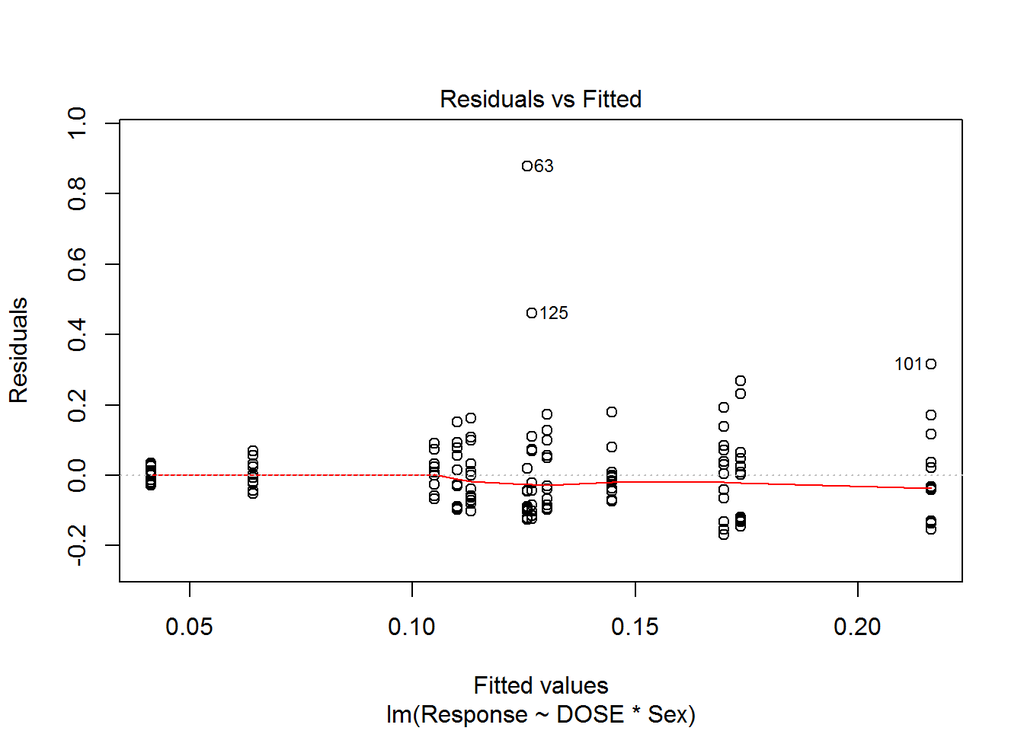

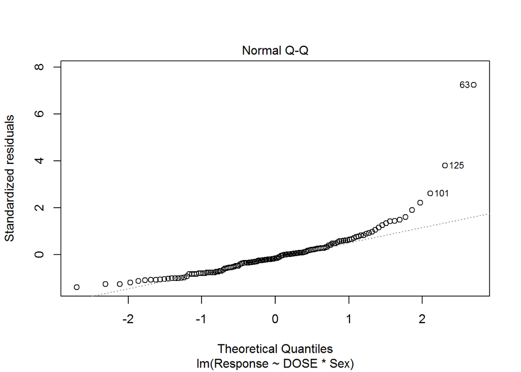

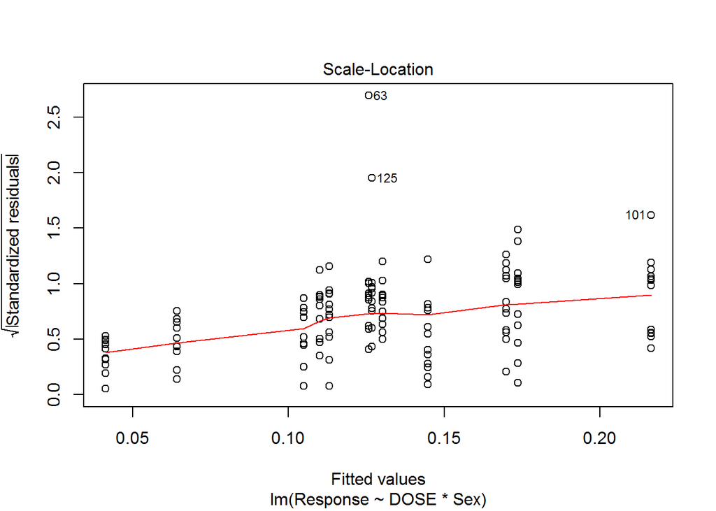

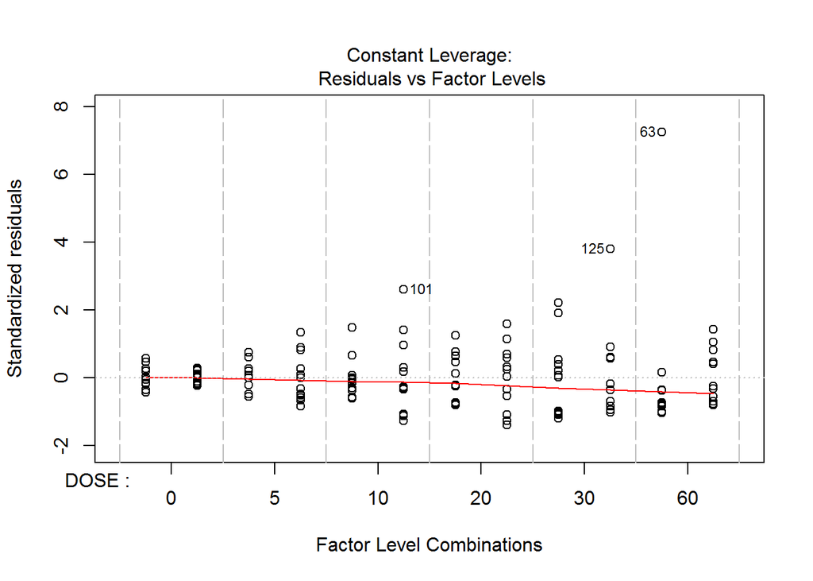

```r
plot(fit)
```

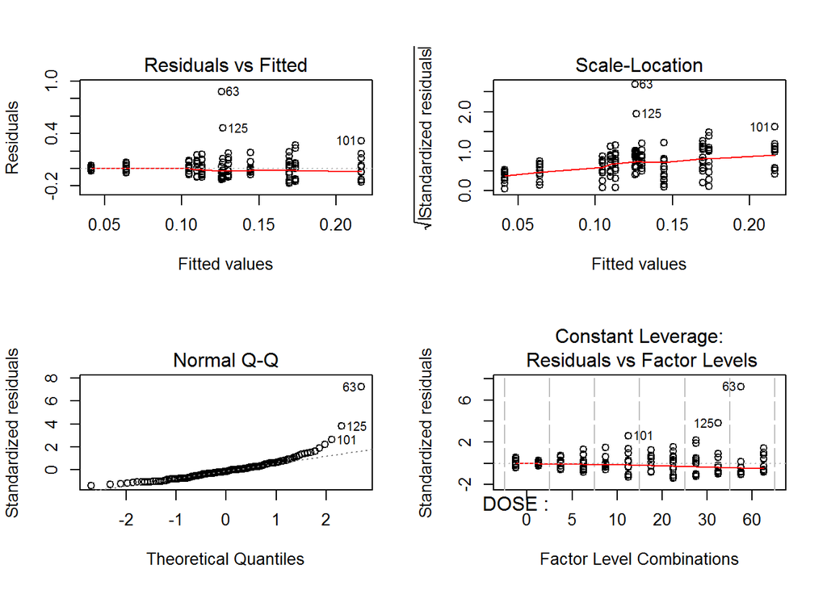

```r
# diagnostic plots
layout(matrix(c(1,2,3,4),2,2)) # optional 4 graphs/page
plot(fit)
```

# Basics of Statistical Analysis Using R (Part 2)

## Multilevel approach: multilevel linear model

- See p. 573 of Discovering Statistics Using R, 1st Edition by Andy Field, Jeremy Miles, Zoe Field.
- Well suited to repeated-measures experimental designs
- Can be modeled using *lme()* function from {nlme} package
- General format: lme.model<-lme(outcome ~ predictor(s), random = random effects, data = dataFrame, method=“ML”)
- The default method is restricted maximum-likelihood estimation (REML)
- For various reasons I am not competent enough to discuss here, the advised method is maximum likelihood (ML)
- “random” specifies any random effects - an effect that can vary across different entities
- In the example below we have *random=~1 | Subject/DOSE/Sex* which means that the data with the same value of *Subject* within different levels of *DOSE* or *Sex* are dependent (i.e., from the same subject)

### Step by Step: Using multilevel approach

1. Build a model from a baseline that includes no predictors other than intercept.
2. Add predictor 1 (DOSE)
3. Add predictor 2 (Sex)
4. Add interaction (Dose:Sex)
5. Compare models to the baseline using anova
6. Determine if adding predictors and/or interaction significantly improved the model**
7. Run appropriate “summary” on the model of interest which will give you all the effects and comparisons***

** When added predictor significantly improves a model, in other words the predictor had a significant effect on dependent measure, we can record this as such:

$$\chi^2(2)=9.1, p=.010$$

Where (2) is an increase of degrees of freedom from baseline, in this case by 2

*** When reporting contrasts from “summary” output we can print it as such:

$$b=2.19, t(38)=3.18, p=.003$$

See Andy Field pages 595-596

```r
# Build a baseline: no predictors other than the intercept

baseline<-lme(Response~1, random=~1 | Subject/DOSE/Sex, data=mydataset, method="ML")

# note that the outcome is predicted only from the intercept (Response~1)
# and we asked to use ML to estimate the model
# the variables DOSE/Sex are nested within the variable Subject (scores for levels of thes variables can be found within each Sbuject)
# to see the effect of each predictor we need to add them one by one
# lets add "DOSE" variable to the model

doseModel<-update(baseline, .~. +DOSE)

# note that we created new model "doseModel" so we can compare it to "baseline" above if need it
# note that we used update function to simply update the model above without rewriting most of it
# next, we can keep buildign the modely by adding "Sex" variable to the "doseModel"


sexModel<-update(doseModel, .~. +Sex)

# note that we created a new model "sexModel" using "update" function
# next, lets add interaction term

mixModel<-update(sexModel, .~. +DOSE:Sex)

# to compare these models we can list them in the order in which we want them to be compared using anova() function

anova(baseline, doseModel, sexModel, mixModel)
```

```
##           Model df       AIC       BIC    logLik   Test   L.Ratio p-value
## baseline      1  5 -170.5782 -155.7291  90.28910
## doseModel     2 10 -175.3117 -145.6136  97.65585 1 vs 2 14.733493  0.0116
## sexModel      3 11 -173.6037 -140.9358  97.80186 2 vs 3  0.292029  0.5889
## mixModel      4 16 -168.0933 -120.5763 100.04666 3 vs 4  4.489601  0.4813
```

```r
# We can further explore the model by runnign summary function

summary(doseModel)
```

```
## Linear mixed-effects model fit by maximum likelihood
##  Data: mydataset
##         AIC       BIC   logLik
##   -175.3117 -145.6136 97.65585
##
## Random effects:
##  Formula: ~1 | Subject
##         (Intercept)
## StdDev:  0.02775878
##
##  Formula: ~1 | DOSE %in% Subject
##         (Intercept)
## StdDev:  0.08213357
##
##  Formula: ~1 | Sex %in% DOSE %in% Subject
##         (Intercept)   Residual
## StdDev:  0.08213372 0.03011343
##
## Fixed effects: Response ~ DOSE
##                  Value  Std.Error  DF  t-value p-value
## (Intercept) 0.05277778 0.02568136 115 2.055101  0.0421
## DOSE5       0.05625000 0.03538446 115 1.589681  0.1147
## DOSE10      0.12777778 0.03538446 115 3.611127  0.0005
## DOSE20      0.08715278 0.03538446 115 2.463024  0.0153
## DOSE30      0.09739583 0.03538446 115 2.752503  0.0069
## DOSE60      0.07517361 0.03538446 115 2.124481  0.0358
##  Correlation:
##        (Intr) DOSE5  DOSE10 DOSE20 DOSE30
## DOSE5  -0.689
## DOSE10 -0.689  0.500
## DOSE20 -0.689  0.500  0.500
## DOSE30 -0.689  0.500  0.500  0.500
## DOSE60 -0.689  0.500  0.500  0.500  0.500
##
## Standardized Within-Group Residuals:
##         Min          Q1         Med          Q3         Max
## -0.29020417 -0.16813399 -0.03650109  0.09515738  1.79139321
##
## Number of Observations: 144
## Number of Groups:
##                    Subject          DOSE %in% Subject
##                         24                        144
## Sex %in% DOSE %in% Subject
##                        144
```

```r
# this give us all the comparisons to 0 we need!
# next lets explore sexModel

summary(sexModel)
```

```
## Linear mixed-effects model fit by maximum likelihood
##  Data: mydataset
##         AIC       BIC   logLik
##   -173.6037 -140.9358 97.80186
##
## Random effects:
##  Formula: ~1 | Subject
##         (Intercept)
## StdDev:  0.02705933
##
##  Formula: ~1 | DOSE %in% Subject
##         (Intercept)
## StdDev:  0.08215392
##
##  Formula: ~1 | Sex %in% DOSE %in% Subject
##         (Intercept)   Residual
## StdDev:  0.08215286 0.03000552
##
## Fixed effects: Response ~ DOSE + Sex
##                  Value  Std.Error  DF  t-value p-value
## (Intercept) 0.04658565 0.02828135 115 1.647222  0.1022
## DOSE5       0.05625000 0.03551337 115 1.583911  0.1160
## DOSE10      0.12777778 0.03551337 115 3.598019  0.0005
## DOSE20      0.08715278 0.03551337 115 2.454084  0.0156
## DOSE30      0.09739583 0.03551337 115 2.742512  0.0071
## DOSE60      0.07517361 0.03551337 115 2.116770  0.0364
## SexM        0.01238426 0.02342370  22 0.528706  0.6023
##  Correlation:
##        (Intr) DOSE5  DOSE10 DOSE20 DOSE30 DOSE60
## DOSE5  -0.628
## DOSE10 -0.628  0.500
## DOSE20 -0.628  0.500  0.500
## DOSE30 -0.628  0.500  0.500  0.500
## DOSE60 -0.628  0.500  0.500  0.500  0.500
## SexM   -0.414  0.000  0.000  0.000  0.000  0.000
##
## Standardized Within-Group Residuals:
##         Min          Q1         Med          Q3         Max
## -0.29571336 -0.15912277 -0.04198563  0.09358681  1.79642306
##
## Number of Observations: 144
## Number of Groups:
##                    Subject          DOSE %in% Subject
##                         24                        144
## Sex %in% DOSE %in% Subject
##                        144
```

```r
# looks like there "Sex" did not significantly contribued to the variance
# finally lets explore mixModel

summary(mixModel)
```

```
## Linear mixed-effects model fit by maximum likelihood
##  Data: mydataset
##         AIC       BIC   logLik
##   -168.0933 -120.5763 100.0467
##
## Random effects:
##  Formula: ~1 | Subject
##         (Intercept)
## StdDev:  0.02864145
##
##  Formula: ~1 | DOSE %in% Subject
##         (Intercept)
## StdDev:  0.08057582
##
##  Formula: ~1 | Sex %in% DOSE %in% Subject
##         (Intercept)   Residual
## StdDev:  0.08057589 0.02974902
##
## Fixed effects: Response ~ DOSE + Sex + DOSE:Sex
##                   Value  Std.Error  DF    t-value p-value
## (Intercept)  0.06423611 0.03654421 110  1.7577643  0.0816
## DOSE5        0.04062500 0.05021760 110  0.8089793  0.4203
## DOSE10       0.08055556 0.05021760 110  1.6041299  0.1116
## DOSE20       0.04583333 0.05021760 110  0.9126946  0.3634
## DOSE30       0.10937500 0.05021760 110  2.1780213  0.0315
## DOSE60       0.06145833 0.05021760 110  1.2238405  0.2236
## SexM        -0.02291667 0.05168132  22 -0.4434226  0.6618
## DOSE5:SexM   0.03125000 0.07101841 110  0.4400267  0.6608
## DOSE10:SexM  0.09444444 0.07101841 110  1.3298586  0.1863
## DOSE20:SexM  0.08263889 0.07101841 110  1.1636263  0.2471
## DOSE30:SexM -0.02395833 0.07101841 110 -0.3373538  0.7365
## DOSE60:SexM  0.02743056 0.07101841 110  0.3862457  0.7001
##  Correlation:
##             (Intr) DOSE5  DOSE10 DOSE20 DOSE30 DOSE60 SexM   DOSE5:
## DOSE5       -0.687
## DOSE10      -0.687  0.500
## DOSE20      -0.687  0.500  0.500
## DOSE30      -0.687  0.500  0.500  0.500
## DOSE60      -0.687  0.500  0.500  0.500  0.500
## SexM        -0.707  0.486  0.486  0.486  0.486  0.486
```

[output cut: 13 more lines]

```
## DOSE10:SexM
## DOSE20:SexM  0.500
## DOSE30:SexM  0.500   0.500
## DOSE60:SexM  0.500   0.500   0.500
##
## Standardized Within-Group Residuals:
##         Min          Q1         Med          Q3         Max
## -0.32617380 -0.15758308 -0.02620577  0.07317072  1.83526769
##
## Number of Observations: 144
## Number of Groups:
##                    Subject          DOSE %in% Subject
##                         24                        144
## Sex %in% DOSE %in% Subject
##                        144
```